# 1 Background

As a statistical consultant working for a real estate investment firm, your task is to develop a model to predict the selling price of a given home in Ames, Iowa. Your employer hopes to use this information to help assess whether the asking price of a house is higher or lower than the true value of the house. If the home is undervalued, it may be a good investment for the firm.

# 2 Training Data

In order to better assess the quality of the model you will produce, the data have been randomly divided into three separate pieces: a training data set, a testing data set, and a validation data set.

```r
library(statsr)
library(tidyverse)
library(dplyr)
library(BAS)
library(MASS)
```

Lets load the data

```r
load("ames_train.Rdata")
load("ames_test.Rdata")
load("ames_validation.Rdata")
```

## 2.1 Part 1 - Exploratory Data Analysis (EDA)

When you first get your data, it’s very tempting to immediately begin fitting models and assessing how they perform. However, before you begin modeling, it’s absolutely essential to explore the structure of the data and the relationships between the variables in the data set.

Do a detailed EDA of the ames_train data set, to learn about the structure of the data and the relationships between the variables in the data set (refer to Introduction to Probability and Data, Week 2, for a reminder about EDA if needed). Your EDA should involve creating and reviewing many plots/graphs and considering the patterns and relationships you see.

After you have explored completely, submit the three graphs/plots that you found most informative during your EDA process, and briefly explain what you learned from each (why you found each informative).

### 2.1.1 BOX Plots

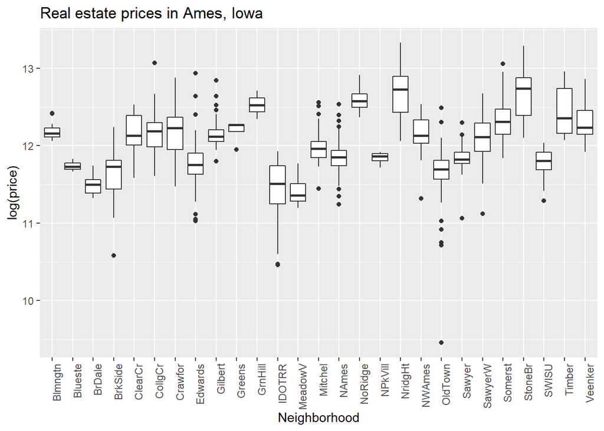

```r
ggplot(data=ames_train, aes(x=Neighborhood, y=log(price))) + geom_boxplot() + labs(title = "Real estate prices in Ames, Iowa", x= "Neighborhood", y= "log(price)") + theme(axis.text.x = element_text(angle=90, hjust=1))
```

Lets modify our data a little bit.

```r
ames_train_tmp <- ames_train[-c(276, 310, 428),]

ames_train_modified <- ames_train_tmp
ames_train_modified$factor_MS.SubClass <- as.factor(ames_train_modified$MS.SubClass)
ames_train_modified$log_Price <- log(ames_train_modified$price)
ames_train_modified$log_Lot.Area <- log(ames_train_modified$Lot.Area)
ames_train_modified$Total.Bath <- ames_train_modified$Full.Bath + ames_train_modified$Half.Bath * 0.5

yearnow <- 2020
ames_train_modified$Property.Age <- (yearnow-ames_train_modified$Year.Built)
ames_train_modified <-
ames_train_modified %>%
  mutate(
    Neighborhood.Class = case_when(
      Neighborhood == "StoneBr" | Neighborhood == "NridgHt" |Neighborhood == "NoRidge" |Neighborhood == "GrnHill" |Neighborhood == "Timber"  ~ "High",
      Neighborhood == "SawyerW" | Neighborhood == "Gilbert" |Neighborhood == "ClearCr" |Neighborhood == "NWAmes"  |Neighborhood == "Blmngtn" | Neighborhood == "CollgCr" |Neighborhood == "Crawfor" |Neighborhood == "Venker"  |Neighborhood == "Greens"  | Neighborhood == "Somerst" ~ "Medium",
      TRUE ~ "Low"
    )
  )
```

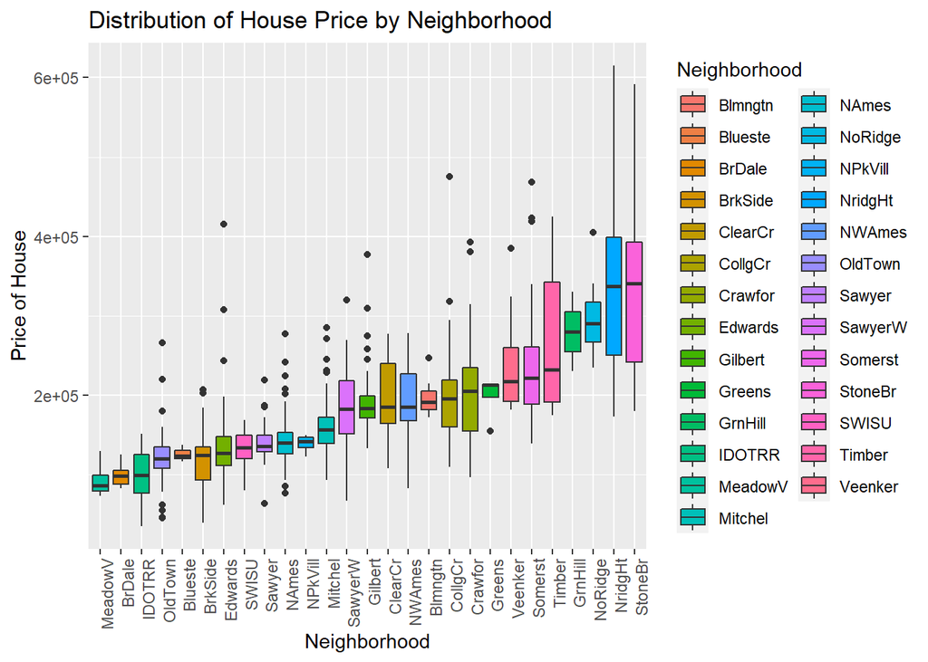

```r
ggplot(data=ames_train_modified, aes(x = fct_reorder(Neighborhood, price), y = price , fill = Neighborhood))+
  geom_boxplot()+
  theme(axis.text.x=element_text(angle=90, hjust=1))+
  labs(title = "Distribution of House Price by Neighborhood", x="Neighborhood", y = "Price of House")
```

Property location is always considered to be an important factor in house price, so this plot was created to explore this further in the Ames data using the variable Neighborhood. As can be seen, there is a very large difference between house prices in Neighborhoods “MeadowV” and “StoneBr”. Because of the large number of Neighborhoods in the dataset, a new variable “Neighborhood.Class” was created and all Neighborhoods classified as “Low”, “Medium”, or “High”.

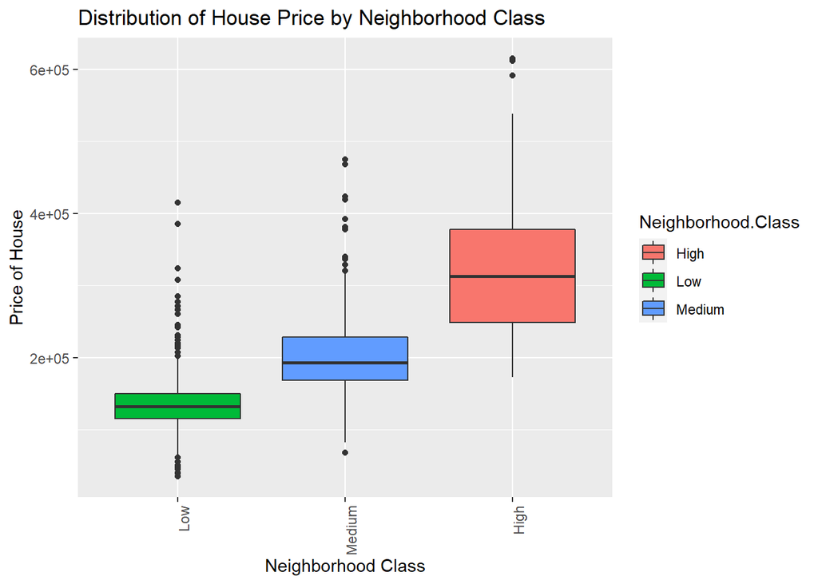

```r
 ggplot(data=ames_train_modified, aes(x = fct_reorder(Neighborhood.Class, price), y = price , fill = Neighborhood.Class))+
  geom_boxplot()+
  theme(axis.text.x=element_text(angle=90, hjust=1))+
  labs(title = "Distribution of House Price by Neighborhood Class", x="Neighborhood Class", y = "Price of House")
```

As can be seen, this plot shows the 3 level “Neighborhood.Class” equivalent of the previous chart. There are very clear boundaries price differentials between each class.

### 2.1.2 Log-transformed price versus log-transformed area

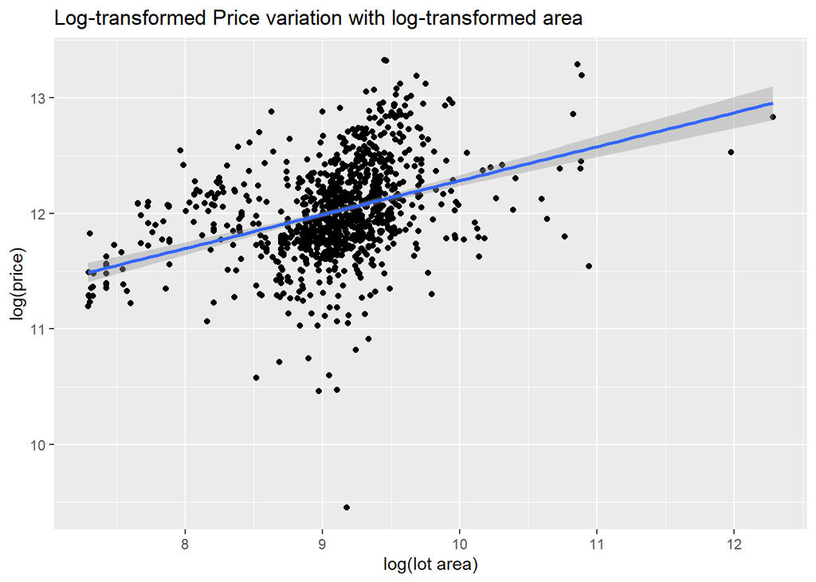

```r
ggplot(data=ames_train, aes(x=log(Lot.Area), y=log(price))) + geom_point() + geom_smooth(method="lm") + labs(title = "Log-transformed Price variation with log-transformed area", x="log(lot area)", y="log(price)")
```

The importance of log-transformation could not be better illustrated than here. Since the distribution of prices is right-skewed, every marginal increase leads to a higher price of the property. When both prices and lot area (footage) are log-transformed, they show a positive linear trend.

### 2.1.3 Overall Quality and Price

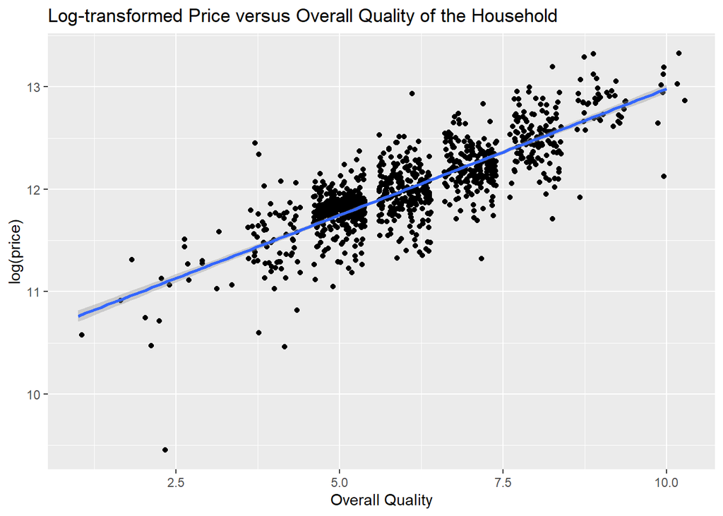

```r
ggplot(data=ames_train, aes(x=Overall.Qual, y=log(price))) + geom_jitter() + geom_smooth(method="lm") + labs(title = "Log-transformed Price versus Overall Quality of the Household", x="Overall Quality", y="log(price)")
```

The plot suggests that there is a strong association between overall quality of a household and its price. In the earlier assignments, this categorical variable was excluded from the multivariate model. Thus, it should be included in the multiple regression model to get a better prediction of house property.

## 2.2 Part 2 - Development and assessment of an initial model, following a semi-guided process of analysis

### 2.2.1 Section 2.1 An Initial Model

In building a model, it is often useful to start by creating a simple, intuitive initial model based on the results of the exploratory data analysis. (Note: The goal at this stage is not to identify the “best” possible model but rather to choose a reasonable and understandable starting point. Later you will expand and revise this model to create your final model.

Based on your EDA, select at most 10 predictor variables from “ames_train” and create a linear model for price (or a transformed version of price) using those variables. Provide the R code and the summary output table for your model, a brief justification for the variables you have chosen, and a brief discussion of the model results in context (focused on the variables that appear to be important predictors and how they relate to sales price).

Based on my EDA, following predictors will be used to arrive at a parsimonious model using

```r
init_model <- lm(log(price) ~ log(Lot.Area) + MS.SubClass + Overall.Qual + Overall.Cond + Heating.QC + Year.Built + House.Style + Neighborhood + Exterior.1st, data = ames_train)
```

### 2.2.2 Sction 2.2 Model Selection

Now either using BAS another stepwise selection procedure choose the “best” model you can, using your initial model as your starting point. Try at least two different model selection methods and compare their results. Do they both arrive at the same model or do they disagree? What do you think this means?

Let us use AIC model selection method to arrive at a parsimonious model.

```r
init_model_AIC <- stepAIC(init_model, direction = 'backward', trace = FALSE)
```

```r
init_model_BIC <- stepAIC(init_model, direction = 'backward', k=log(nrow(ames_train)), trace = FALSE)
```

Since the objective of this assignment is to predict the house property prices, we will use AIC method to arrive at a parsimonious model.

### 2.2.3 Section 2.3 Initial Model Residuals

One way to assess the performance of a model is to examine the model’s residuals. In the space below, create a residual plot for your preferred model from above and use it to assess whether your model appears to fit the data well. Comment on any interesting structure in the residual plot (trend, outliers, etc.) and briefly discuss potential implications it may have for your model and inference / prediction you might produce.

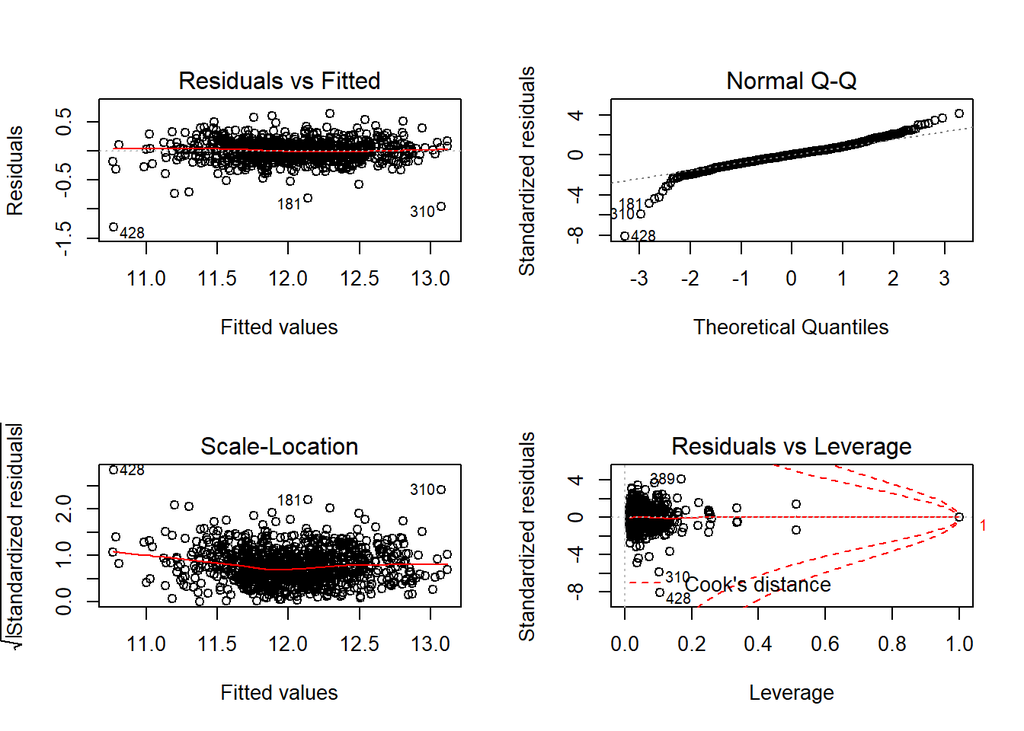

```r
par(mfrow=c(2,2))
plot(init_model_AIC)
```

### 2.2.4 Section 2.4 Initial Model RMSE

You can calculate it directly based on the model output. Be specific about the units of your RMSE (depending on whether you transformed your response variable). The value you report will be more meaningful if it is in the original units (dollars).

```r
predict_init <- exp(predict(init_model_AIC, ames_train))
resid_init <- ames_train$price - predict_init
rmse_init <- sqrt(mean(resid_init^2))
rmse_init
```

```
## [1] 33794.63
```

The RMSE was calculated based on AIC model output. Since we used log-transformed price in the initial model, the RMSE comes out to be 33794.6 dollars.

### 2.2.5 Section 2.5 Overfitting

The process of building a model generally involves starting with an initial model (as you have done above), identifying its shortcomings, and adapting the model accordingly. This process may be repeated several times until the model fits the data reasonably well. However, the model may do well on training data but perform poorly out-of-sample (meaning, on a dataset other than the original training data) because the model is overly-tuned to specifically fit the training data. This is called “overfitting.” To determine whether overfitting is occurring on a model, compare the performance of a model on both in-sample and out-of-sample data sets. To look at performance of your initial model on out-of-sample data, you will use the data set ames_test.

Use your model from above to generate predictions for the housing prices in the test data set. Are the predictions significantly more accurate (compared to the actual sales prices) for the training data than the test data? Why or why not? Briefly explain how you determined that (what steps or processes did you use)?

The following errors occured while predicting the values from test dataset: factor House.Style has new levels 2.5Fin factor Neighborhood has new levels Landmrk factor Exterior.1st has new levels AsphShn Since the no. of observations is very small, we will eliminate these observations from our test model

```r
ames_test <- ames_test %>% filter(House.Style != '2.5Fin') %>% filter(Neighborhood != 'Landmrk') %>% filter(Exterior.1st != 'AsphShn')
predict_test <- exp(predict(init_model_AIC, ames_test))
resid_test <- ames_test$price - predict_test
rmse_test <- sqrt(mean(resid_test^2))
rmse_test
```

```
## [1] 31670.79
```

The value of RMSE decreases to 31670.79 dollars for out-of-sample prediction. This indicates that the model predicts the values of prices for test dataset better than the training dataset. Hence, there does not appear to be a case of overfilling.

# 3 Development of a Final Model

Now that you have developed an initial model to use as a baseline, create a final model with at most 20 variables to predict housing prices in Ames, IA, selecting from the full array of variables in the dataset and using any of the tools that we introduced in this specialization.

Carefully document the process that you used to come up with your final model, so that you can answer the questions below.

## 3.1 Final Model

Provide the summary table for your model.

```r
summary(init_model_AIC)
```

```
##
## Call:
## lm(formula = log(price) ~ log(Lot.Area) + Overall.Qual + Overall.Cond +
##     Heating.QC + Year.Built + House.Style + Neighborhood + Exterior.1st,
##     data = ames_train)
##
## Residuals:
##      Min       1Q   Median       3Q      Max
## -1.31066 -0.08985  0.00158  0.08674  0.64251
##
## Coefficients:
##                       Estimate Std. Error t value Pr(>|t|)
## (Intercept)          0.6352289  1.0300734   0.617 0.537592
## log(Lot.Area)        0.2325865  0.0149105  15.599  < 2e-16 ***
## Overall.Qual         0.1344092  0.0067553  19.897  < 2e-16 ***
## Overall.Cond         0.0516859  0.0058975   8.764  < 2e-16 ***
## Heating.QCFa        -0.1358536  0.0401611  -3.383 0.000747 ***
## Heating.QCGd        -0.0116602  0.0179630  -0.649 0.516415
## Heating.QCPo        -0.0116190  0.1866220  -0.062 0.950369
## Heating.QCTA        -0.0827052  0.0163336  -5.064 4.94e-07 ***
## Year.Built           0.0041618  0.0005052   8.238 5.79e-16 ***
## House.Style1.5Unf   -0.1689145  0.0691954  -2.441 0.014824 *
## House.Style1Story   -0.0874118  0.0225137  -3.883 0.000111 ***
## House.Style2.5Unf    0.0471196  0.0591657   0.796 0.425999
## House.Style2Story   -0.0199645  0.0241500  -0.827 0.408621
## House.StyleSFoyer   -0.0494865  0.0376968  -1.313 0.189585
## House.StyleSLvl     -0.0721761  0.0352071  -2.050 0.040635 *
## NeighborhoodBlueste -0.1131167  0.1156317  -0.978 0.328201
## NeighborhoodBrDale  -0.1992258  0.0810996  -2.457 0.014206 *
## NeighborhoodBrkSide -0.1987885  0.0681332  -2.918 0.003610 **
## NeighborhoodClearCr -0.1428290  0.0788272  -1.812 0.070314 .
## NeighborhoodCollgCr -0.1935472  0.0580352  -3.335 0.000886 ***
## NeighborhoodCrawfor -0.0095973  0.0678381  -0.141 0.887526
## NeighborhoodEdwards -0.2090711  0.0615622  -3.396 0.000712 ***
## NeighborhoodGilbert -0.2298298  0.0617679  -3.721 0.000210 ***
## NeighborhoodGreens   0.0069090  0.1033573   0.067 0.946718
## NeighborhoodGrnHill  0.1547293  0.1343528   1.152 0.249749
## NeighborhoodIDOTRR  -0.3312206  0.0695848  -4.760 2.24e-06 ***
## NeighborhoodMeadowV -0.2197962  0.0836169  -2.629 0.008712 **
## NeighborhoodMitchel -0.1641122  0.0629687  -2.606 0.009298 **
```

[output cut: 15 more lines]

```
## Exterior.1stCemntBd  0.2500855  0.0652484   3.833 0.000135 ***
## Exterior.1stHdBoard  0.1605346  0.0547937   2.930 0.003473 **
## Exterior.1stImStucc  0.0932965  0.1829511   0.510 0.610203
## Exterior.1stMetalSd  0.2089201  0.0536592   3.893 0.000106 ***
## Exterior.1stPlywood  0.1993373  0.0571638   3.487 0.000511 ***
## Exterior.1stStucco   0.2546777  0.0691839   3.681 0.000245 ***
## Exterior.1stVinylSd  0.1799422  0.0544476   3.305 0.000986 ***
## Exterior.1stWd Sdng  0.1884032  0.0539322   3.493 0.000499 ***
## Exterior.1stWdShing  0.1743663  0.0641122   2.720 0.006653 **
## ---
## Signif. codes:  0 '***' 0.001 '**' 0.01 '*' 0.05 '.' 0.1 ' ' 1
##
## Residual standard error: 0.1713 on 948 degrees of freedom
## Multiple R-squared:  0.8425, Adjusted R-squared:  0.8341
## F-statistic: 99.47 on 51 and 948 DF,  p-value: < 2.2e-16
```

## 3.2 Transformation

Did you decide to transform any variables? Why or why not? Explain in a few sentences.

Yes. The model uses log-transformations of variables price and Lot.Area. This is because with a marginal increase in the lot area (square footage), the price of the real estate property goes up. Thus, there is an exponential relationship between the Lot.Area and price.

In order to fit a linear model to the Lot.Area and price, we have to log-transform these variables. The graph below suggests the result of transformation. There is clearly a better linear fit with log-transformation

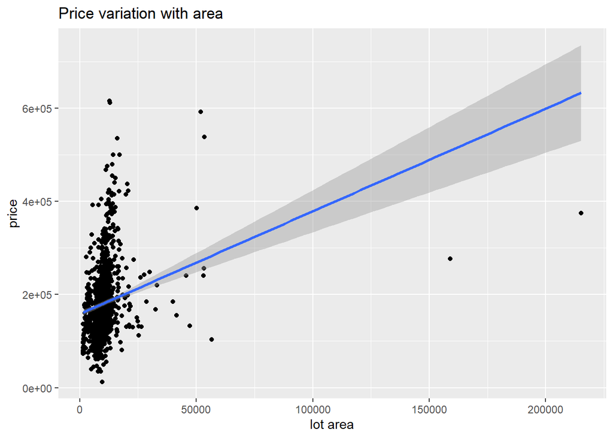

```r
par(mfrow=c(1,2))

ggplot(data=ames_train, aes(x=Lot.Area, y=price)) + geom_point() + geom_smooth(method="lm") + labs(title = "Price variation with area", x="lot area", y="price")
```

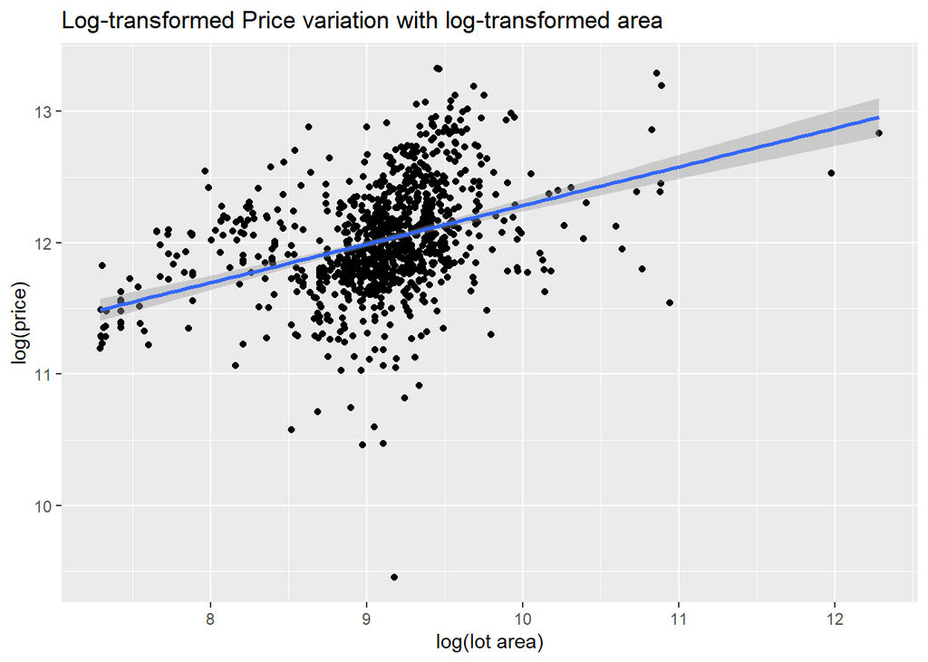

```r
ggplot(data=ames_train, aes(x=log(Lot.Area), y=log(price))) + geom_point() + geom_smooth(method="lm") + labs(title = "Log-transformed Price variation with log-transformed area", x="log(lot area)", y="log(price)")
```

## 3.3 Variable Interaction

Did you decide to include any variable interactions? Why or why not? Explain in a few sentences.

## 3.4 Variable Selection

What method did you use to select the variables you included? Why did you select the method you used? Explain in a few sentences.

AIC was used in model selection. This is because a frequentist approach with AIC to linear regression will give more penalty to adjusted R-squared value. Since the goal of the assignment is to predict the price of the property, this method is superior to BIC which uses Bayesian reasoning (more penalty to the no. of variables included in the model)

## 3.5 Model Testing

How did testing the model on out-of-sample data affect whether or how you changed your model? Explain in a few sentences.

RMSE was lower for out-of-sample prediction. This suggests that there was no overfitting in the initial model. Thus, final model does not vary from the initial model.

# 4 Final Model Assessment

## 4.1 Final Model Residual

For your final model, create and briefly interpret an informative plot of the residuals.

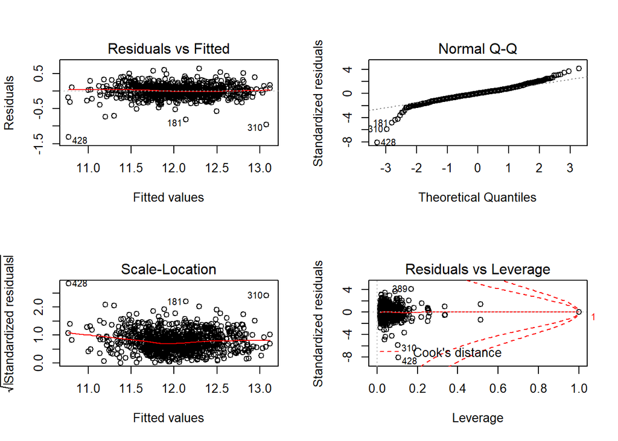

```r
par(mfrow=c(2,2))
plot(init_model_AIC)
```

## 4.2 Final Model RMSE

For your final model, calculate and briefly comment on the RMSE.

## 4.3 Final Model Evaluation

What are some strengths and weaknesses of your model?

The model has a high RMSE value. Thus, the predictive performance can be improved by including other variables at the cost of lower parsimony.

## 4.4 Final Model Validation

Testing your final model on a separate, validation data set is a great way to determine how your model will perform in real-life practice.

You will use the “ames_validation” dataset to do some additional assessment of your final model. Discuss your findings, be sure to mention: * What is the RMSE of your final model when applied to the validation data? * How does this value compare to that of the training data and/or testing data? * What percentage of the 95% predictive confidence (or credible) intervals contain the true price of the house in the validation data set? * From this result, does your final model properly reflect uncertainty?

```r
ames_validation <- ames_validation %>% filter(House.Style != '2.5Fin') %>% filter(Neighborhood != 'Landmrk') %>% filter(Exterior.1st != 'AsphShn') %>% filter(Exterior.1st != 'CBlock') %>% filter(Exterior.1st != 'PreCast')
predict_valid <- exp(predict(init_model_AIC, ames_validation))
resid_valid <- ames_validation$price - predict_valid
rmse_valid <- sqrt(mean(resid_valid^2))
rmse_valid
```

```
## [1] 28177.37
```

The RMSE for validation dataset turns out to be 28177 dollars. This is lower than both training and test dataset values, suggesting that no overfitting was done.

```r
predict_CI <- exp(predict(init_model_AIC, ames_validation, interval = "prediction", level = 0.95))
coverage.prob.full <- mean(ames_validation$price > predict_CI[,"lwr"] & ames_validation$price < predict_CI[,"upr"])
coverage.prob.full
```

```
## [1] 0.9748677
```

# 5 Conclusion

Provide a brief summary of your results, and a brief discussion of what you have learned about the data and your model.

The linear model had an adjusted R-squared value of 0.834 based on AIC backward model selection method. The comparison of RMSE values between training and test data set suggests that there is no possible overfitting in the linear model.

The linear model was able to predict over 97% of values in the validation dataset. Thus, the model is a very good predictor of real-life real estate prices.